# 30535 Skills Problem Set 2

# 3.2 Filter rows with filter()

1. Import the nycflights13 library, which comes with a data set called flights. Find all flights that

```r
library(nycflights13)
flights <- nycflights13::flights
```

1-1. Had an arrival delay of three or more hours

```r
filter(flights, arr_delay >=3)
```

```
## # A tibble: 123,096 x 19
##     year month   day dep_time sched_dep_time dep_delay arr_time
##    <int> <int> <int>    <int>          <int>     <dbl>    <int>
##  1  2013     1     1      517            515         2      830
##  2  2013     1     1      533            529         4      850
##  3  2013     1     1      542            540         2      923
##  4  2013     1     1      554            558        -4      740
##  5  2013     1     1      555            600        -5      913
##  6  2013     1     1      558            600        -2      753
##  7  2013     1     1      558            600        -2      924
##  8  2013     1     1      559            600        -1      941
##  9  2013     1     1      600            600         0      837
## 10  2013     1     1      602            605        -3      821
## # … with 123,086 more rows, and 12 more variables: sched_arr_time <int>,
## #   arr_delay <dbl>, carrier <chr>, flight <int>, tailnum <chr>,
## #   origin <chr>, dest <chr>, air_time <dbl>, distance <dbl>, hour <dbl>,
## #   minute <dbl>, time_hour <dttm>
```

1-2. Flew to Houston (IAH or HOU)

```r
dest_vector <- c("IAH", "HOU")
filter(flights, dest %in% dest_vector)
```

```
## # A tibble: 9,313 x 19
##     year month   day dep_time sched_dep_time dep_delay arr_time
##    <int> <int> <int>    <int>          <int>     <dbl>    <int>
##  1  2013     1     1      517            515         2      830
##  2  2013     1     1      533            529         4      850
##  3  2013     1     1      623            627        -4      933
##  4  2013     1     1      728            732        -4     1041
##  5  2013     1     1      739            739         0     1104
##  6  2013     1     1      908            908         0     1228
##  7  2013     1     1     1028           1026         2     1350
##  8  2013     1     1     1044           1045        -1     1352
##  9  2013     1     1     1114            900       134     1447
## 10  2013     1     1     1205           1200         5     1503
## # … with 9,303 more rows, and 12 more variables: sched_arr_time <int>,
## #   arr_delay <dbl>, carrier <chr>, flight <int>, tailnum <chr>,
## #   origin <chr>, dest <chr>, air_time <dbl>, distance <dbl>, hour <dbl>,
## #   minute <dbl>, time_hour <dttm>
```

1-3. Were operated by United, American, or Southwest

```r
carrier_vector <- c("UA","AA", "WN")
filter(flights, carrier %in% carrier_vector)
```

```
## # A tibble: 103,669 x 19
##     year month   day dep_time sched_dep_time dep_delay arr_time
##    <int> <int> <int>    <int>          <int>     <dbl>    <int>
##  1  2013     1     1      517            515         2      830
##  2  2013     1     1      533            529         4      850
##  3  2013     1     1      542            540         2      923
##  4  2013     1     1      554            558        -4      740
##  5  2013     1     1      558            600        -2      753
##  6  2013     1     1      558            600        -2      924
##  7  2013     1     1      558            600        -2      923
##  8  2013     1     1      559            600        -1      941
##  9  2013     1     1      559            600        -1      854
## 10  2013     1     1      606            610        -4      858
## # … with 103,659 more rows, and 12 more variables: sched_arr_time <int>,
## #   arr_delay <dbl>, carrier <chr>, flight <int>, tailnum <chr>,
## #   origin <chr>, dest <chr>, air_time <dbl>, distance <dbl>, hour <dbl>,
## #   minute <dbl>, time_hour <dttm>
```

1-4. Departed in spring (March, April, and May)

```r
month_vector <- c(3, 4, 5)
filter(flights, month %in% month_vector)
```

```
## # A tibble: 85,960 x 19
##     year month   day dep_time sched_dep_time dep_delay arr_time
##    <int> <int> <int>    <int>          <int>     <dbl>    <int>
##  1  2013     3     1        4           2159       125      318
##  2  2013     3     1       50           2358        52      526
##  3  2013     3     1      117           2245       152      223
##  4  2013     3     1      454            500        -6      633
##  5  2013     3     1      505            515       -10      746
##  6  2013     3     1      521            530        -9      813
##  7  2013     3     1      537            540        -3      856
##  8  2013     3     1      541            545        -4     1014
##  9  2013     3     1      549            600       -11      639
## 10  2013     3     1      550            600       -10      747
## # … with 85,950 more rows, and 12 more variables: sched_arr_time <int>,
## #   arr_delay <dbl>, carrier <chr>, flight <int>, tailnum <chr>,
## #   origin <chr>, dest <chr>, air_time <dbl>, distance <dbl>, hour <dbl>,
## #   minute <dbl>, time_hour <dttm>
```

1-5. Arrived more than two hours late, but didn’t leave late

```r
filter(flights, arr_delay >= 120 & dep_delay <= 0)
```

```
## # A tibble: 29 x 19
##     year month   day dep_time sched_dep_time dep_delay arr_time
##    <int> <int> <int>    <int>          <int>     <dbl>    <int>
##  1  2013     1    27     1419           1420        -1     1754
##  2  2013    10     7     1350           1350         0     1736
##  3  2013    10     7     1357           1359        -2     1858
##  4  2013    10    16      657            700        -3     1258
##  5  2013    11     1      658            700        -2     1329
##  6  2013     3    18     1844           1847        -3       39
##  7  2013     4    17     1635           1640        -5     2049
##  8  2013     4    18      558            600        -2     1149
##  9  2013     4    18      655            700        -5     1213
## 10  2013     5    22     1827           1830        -3     2217
## # … with 19 more rows, and 12 more variables: sched_arr_time <int>,
## #   arr_delay <dbl>, carrier <chr>, flight <int>, tailnum <chr>,
## #   origin <chr>, dest <chr>, air_time <dbl>, distance <dbl>, hour <dbl>,
## #   minute <dbl>, time_hour <dttm>
```

1-6. Were delayed by at least an hour, but made up over 30 minutes in flight

```r
flights %>%
  filter(dep_delay >= 60, dep_delay - arr_delay > 30)
```

```
## # A tibble: 1,844 x 19
##     year month   day dep_time sched_dep_time dep_delay arr_time
##    <int> <int> <int>    <int>          <int>     <dbl>    <int>
##  1  2013     1     1     2205           1720       285       46
##  2  2013     1     1     2326           2130       116      131
##  3  2013     1     3     1503           1221       162     1803
##  4  2013     1     3     1839           1700        99     2056
##  5  2013     1     3     1850           1745        65     2148
##  6  2013     1     3     1941           1759       102     2246
##  7  2013     1     3     1950           1845        65     2228
##  8  2013     1     3     2015           1915        60     2135
##  9  2013     1     3     2257           2000       177       45
## 10  2013     1     4     1917           1700       137     2135
## # … with 1,834 more rows, and 12 more variables: sched_arr_time <int>,
## #   arr_delay <dbl>, carrier <chr>, flight <int>, tailnum <chr>,
## #   origin <chr>, dest <chr>, air_time <dbl>, distance <dbl>, hour <dbl>,
## #   minute <dbl>, time_hour <dttm>
```

1-7. Departed between midnight and 5am (inclusive)

```r
filter(flights, dep_time == 2400 | dep_time <= 500)
```

```
## # A tibble: 1,516 x 19
##     year month   day dep_time sched_dep_time dep_delay arr_time
##    <int> <int> <int>    <int>          <int>     <dbl>    <int>
##  1  2013     1     2       42           2359        43      518
##  2  2013     1     2      126           2250       156      233
##  3  2013     1     2      458            500        -2      703
##  4  2013     1     3       32           2359        33      504
##  5  2013     1     3       50           2145       185      203
##  6  2013     1     3      235           2359       156      700
##  7  2013     1     3      458            500        -2      650
##  8  2013     1     4       25           2359        26      505
##  9  2013     1     4      106           2245       141      201
## 10  2013     1     4      456            500        -4      631
## # … with 1,506 more rows, and 12 more variables: sched_arr_time <int>,
## #   arr_delay <dbl>, carrier <chr>, flight <int>, tailnum <chr>,
## #   origin <chr>, dest <chr>, air_time <dbl>, distance <dbl>, hour <dbl>,
## #   minute <dbl>, time_hour <dttm>
```

2. We reproduced a graph from the last problem set. There is one green point that has very low gas mileage. What car is it?
- That green point is minivan with very low gas mileage.

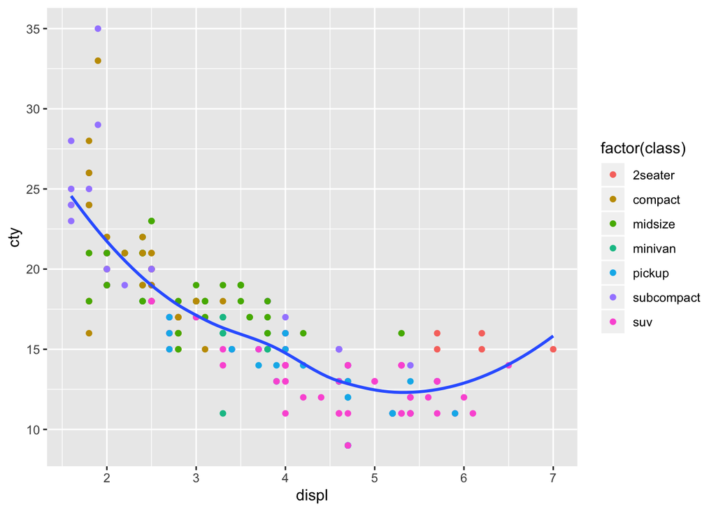

```r
ggplot(mpg) +
  geom_point(mapping = aes(x = displ, y = cty, color = factor(class))) +
  geom_smooth(mapping = aes(x = displ, y = cty), se = FALSE)
```

3. Common bugs: You want to see missing values in a dataframe. You run the following code and get no results. Why is wrong?
- This is because, filter() only includes rows where the condition is TRUE. In other words, filter() excludes both FALSE and NA values. So if one wants to preserve missing values, ask for them explicitly: by putting is.na(x) instead of NA.

```r
filter(flights, is.na(arr_time))
```

```
## # A tibble: 8,713 x 19
##     year month   day dep_time sched_dep_time dep_delay arr_time
##    <int> <int> <int>    <int>          <int>     <dbl>    <int>
##  1  2013     1     1     2016           1930        46       NA
##  2  2013     1     1       NA           1630        NA       NA
##  3  2013     1     1       NA           1935        NA       NA
##  4  2013     1     1       NA           1500        NA       NA
##  5  2013     1     1       NA            600        NA       NA
##  6  2013     1     2     2041           2045        -4       NA
##  7  2013     1     2     2145           2129        16       NA
##  8  2013     1     2       NA           1540        NA       NA
##  9  2013     1     2       NA           1620        NA       NA
## 10  2013     1     2       NA           1355        NA       NA
## # … with 8,703 more rows, and 12 more variables: sched_arr_time <int>,
## #   arr_delay <dbl>, carrier <chr>, flight <int>, tailnum <chr>,
## #   origin <chr>, dest <chr>, air_time <dbl>, distance <dbl>, hour <dbl>,
## #   minute <dbl>, time_hour <dttm>
```

4. How many flights have a missing dep_time? What other variables are missing? What might these rows represent?
- 8255 flights have a missing dep_time, as well as dep_delay, arr_time, arr_delay, air_time, and sometimes tailnum. These rows might probably represent cancelled flights due to various reasons.

```r
filter(flights, is.na(dep_time))
```

```
## # A tibble: 8,255 x 19
##     year month   day dep_time sched_dep_time dep_delay arr_time
##    <int> <int> <int>    <int>          <int>     <dbl>    <int>
##  1  2013     1     1       NA           1630        NA       NA
##  2  2013     1     1       NA           1935        NA       NA
##  3  2013     1     1       NA           1500        NA       NA
##  4  2013     1     1       NA            600        NA       NA
##  5  2013     1     2       NA           1540        NA       NA
##  6  2013     1     2       NA           1620        NA       NA
##  7  2013     1     2       NA           1355        NA       NA
##  8  2013     1     2       NA           1420        NA       NA
##  9  2013     1     2       NA           1321        NA       NA
## 10  2013     1     2       NA           1545        NA       NA
## # … with 8,245 more rows, and 12 more variables: sched_arr_time <int>,
## #   arr_delay <dbl>, carrier <chr>, flight <int>, tailnum <chr>,
## #   origin <chr>, dest <chr>, air_time <dbl>, distance <dbl>, hour <dbl>,
## #   minute <dbl>, time_hour <dttm>
```

5. What happens to observations with missing values in arr_time when you filter by arr_time == 1800? Why?
- If you filter for arr_time == 1800, observations of missing value for arr_time is not included in the resulting data frame.

```r
filter(flights, arr_time == 1800)
```

```
## # A tibble: 407 x 19
##     year month   day dep_time sched_dep_time dep_delay arr_time
##    <int> <int> <int>    <int>          <int>     <dbl>    <int>
##  1  2013     1     2     1442           1430        12     1800
##  2  2013     1     2     1600           1501        59     1800
##  3  2013     1     2     1603           1517        46     1800
##  4  2013     1     3     1602           1600         2     1800
##  5  2013     1     4     1658           1705        -7     1800
##  6  2013     1     5     1607           1615        -8     1800
##  7  2013     1     7     1706           1710        -4     1800
##  8  2013     1     8     1451           1455        -4     1800
##  9  2013     1    10     1525           1530        -5     1800
## 10  2013     1    10     1659           1705        -6     1800
## # … with 397 more rows, and 12 more variables: sched_arr_time <int>,
## #   arr_delay <dbl>, carrier <chr>, flight <int>, tailnum <chr>,
## #   origin <chr>, dest <chr>, air_time <dbl>, distance <dbl>, hour <dbl>,
## #   minute <dbl>, time_hour <dttm>
```

6. What does NA | TRUE evaluate to? Why?
- TRUE. Here, NA is holding the place of a logical value, so it could be representing only TRUE or FALSE. But whatever it represents, the answer will be the same as TRUE.
- cf. OR(|) Only one has to be ‘TRUE’ for the whole statement to return ‘TRUE’
- cf. AND(&) Both has to be ‘TRUE’ for the whole statement to return ‘TRUE’
- resource : https://blog.revolutionanalytics.com/2016/07/understanding-na-in-r.html
- resource : https://github.com/harris-coding-lab/harris-coding-lab.github.io/blob/master/slides/03_if-statements.Rmd

```r
NA | TRUE
```

```
## [1] TRUE
```

```r
TRUE | TRUE
```

```
## [1] TRUE
```

```r
FALSE | TRUE
```

```
## [1] TRUE
```

7. What does FALSE & NA evaluate to? Why?
- FALSE. Here, NA is also holding the place of a logical value. Because for AND(&), both has to be ‘TRUE’ for the whole statement to return ‘TRUE’, whatever it represents, here the answer will be the same as FALSE.

```r
FALSE & NA
```

```
## [1] FALSE
```

```r
FALSE & TRUE
```

```
## [1] FALSE
```

```r
FALSE & FALSE
```

```
## [1] FALSE
```

# 3.3 Select columns with select()

1. What happens if you include the name of a variable multiple times in a select() call?
- R returns only 1 column for each variable included in the select(), regardless of number of times included in the select().

```r
select(flights, carrier, carrier, year, day, day, carrier)
```

```
## # A tibble: 336,776 x 3
##    carrier  year   day
##    <chr>   <int> <int>
##  1 UA       2013     1
##  2 UA       2013     1
##  3 AA       2013     1
##  4 B6       2013     1
##  5 DL       2013     1
##  6 UA       2013     1
##  7 B6       2013     1
##  8 EV       2013     1
##  9 B6       2013     1
## 10 AA       2013     1
## # … with 336,766 more rows
```

```r
select(flights, contains(ignore.case = FALSE, "TIME"))
```

```
## # A tibble: 336,776 x 0
```

3. Brainstorm as many distinct ways as possible to select dep_time, dep_delay, arr_time, arr_delay from flights.

```r
#1
select(flights, starts_with("dep_time"), contains("dep_delay"), starts_with("arr"), contains("arr_dely"))
```

```
## # A tibble: 336,776 x 4
##    dep_time dep_delay arr_time arr_delay
##       <int>     <dbl>    <int>     <dbl>
##  1      517         2      830        11
##  2      533         4      850        20
##  3      542         2      923        33
##  4      544        -1     1004       -18
##  5      554        -6      812       -25
##  6      554        -4      740        12
##  7      555        -5      913        19
##  8      557        -3      709       -14
##  9      557        -3      838        -8
## 10      558        -2      753         8
## # … with 336,766 more rows
```

```r
#2
select(flights, starts_with("dep"), starts_with("arr"))
```

```
## # A tibble: 336,776 x 4
##    dep_time dep_delay arr_time arr_delay
##       <int>     <dbl>    <int>     <dbl>
##  1      517         2      830        11
##  2      533         4      850        20
##  3      542         2      923        33
##  4      544        -1     1004       -18
##  5      554        -6      812       -25
##  6      554        -4      740        12
##  7      555        -5      913        19
##  8      557        -3      709       -14
##  9      557        -3      838        -8
## 10      558        -2      753         8
## # … with 336,766 more rows
```

```r
#3
contain_vector1 <- c("dep")
contain_vector2 <- c("arr_")
select(flights, contains(contain_vector1), contains(contain_vector2), -contains("sched"))
```

```
## # A tibble: 336,776 x 4
##    dep_time dep_delay arr_time arr_delay
##       <int>     <dbl>    <int>     <dbl>
##  1      517         2      830        11
##  2      533         4      850        20
##  3      542         2      923        33
##  4      544        -1     1004       -18
##  5      554        -6      812       -25
##  6      554        -4      740        12
##  7      555        -5      913        19
##  8      557        -3      709       -14
##  9      557        -3      838        -8
## 10      558        -2      753         8
## # … with 336,766 more rows
```

```r
#4
select(flights, starts_with("dep"), contains("dep"), starts_with("arr_"), contains("arr_"), -contains("sched"))
```

```
## # A tibble: 336,776 x 4
##    dep_time dep_delay arr_time arr_delay
##       <int>     <dbl>    <int>     <dbl>
##  1      517         2      830        11
##  2      533         4      850        20
##  3      542         2      923        33
##  4      544        -1     1004       -18
##  5      554        -6      812       -25
##  6      554        -4      740        12
##  7      555        -5      913        19
##  8      557        -3      709       -14
##  9      557        -3      838        -8
## 10      558        -2      753         8
## # … with 336,766 more rows
```

```r
#5
select(flights, dep_time:dep_delay, arr_time:arr_delay, -contains("sched"))
```

```
## # A tibble: 336,776 x 4
##    dep_time dep_delay arr_time arr_delay
##       <int>     <dbl>    <int>     <dbl>
##  1      517         2      830        11
##  2      533         4      850        20
##  3      542         2      923        33
##  4      544        -1     1004       -18
##  5      554        -6      812       -25
##  6      554        -4      740        12
##  7      555        -5      913        19
##  8      557        -3      709       -14
##  9      557        -3      838        -8
## 10      558        -2      753         8
## # … with 336,766 more rows
```

# 3.4 Sort columns with arrange()

1. Sort flights to find the most delayed flights by arrival time. End your code with %>% head(1) to only print that row.

```r
not_cancelled <- filter(flights, !is.na(arr_time), !is.na(sched_arr_time))
not_cancelled %>%
  arrange(desc(arr_delay)) %>%
  select(arr_delay, everything()) %>%
  head(1)
```

```
## # A tibble: 1 x 19
##   arr_delay  year month   day dep_time sched_dep_time dep_delay arr_time
##       <dbl> <int> <int> <int>    <int>          <int>     <dbl>    <int>
## 1      1272  2013     1     9      641            900      1301     1242
## # … with 11 more variables: sched_arr_time <int>, carrier <chr>,
## #   flight <int>, tailnum <chr>, origin <chr>, dest <chr>, air_time <dbl>,
## #   distance <dbl>, hour <dbl>, minute <dbl>, time_hour <dttm>
```

2. Find the top 5 flights that left earliest relative to their scheduled departure. Only show the tail number, date and number of minutes early they departed at.

```r
not_cancelled <- filter(flights, !is.na(arr_time), !is.na(sched_arr_time))
not_cancelled %>%
  arrange(dep_delay) %>%
  select(tailnum, day, dep_delay) %>%
  head(5)
```

```
## # A tibble: 5 x 3
##   tailnum   day dep_delay
##   <chr>   <int>     <dbl>
## 1 N592JB      7       -43
## 2 N612DL      3       -33
## 3 N825AS     10       -32
## 4 N934DL     11       -30
## 5 N208FR     29       -27
```

3. How could you use arrange() to sort all missing values to the start? (Hint: use is.na()).

```r
tail(is.na(flights)) #looking for missing value containing columns
```

```
##            year month   day dep_time sched_dep_time dep_delay arr_time
## [336771,] FALSE FALSE FALSE     TRUE          FALSE      TRUE     TRUE
## [336772,] FALSE FALSE FALSE     TRUE          FALSE      TRUE     TRUE
## [336773,] FALSE FALSE FALSE     TRUE          FALSE      TRUE     TRUE
## [336774,] FALSE FALSE FALSE     TRUE          FALSE      TRUE     TRUE
## [336775,] FALSE FALSE FALSE     TRUE          FALSE      TRUE     TRUE
## [336776,] FALSE FALSE FALSE     TRUE          FALSE      TRUE     TRUE
##           sched_arr_time arr_delay carrier flight tailnum origin  dest
## [336771,]          FALSE      TRUE   FALSE  FALSE   FALSE  FALSE FALSE
## [336772,]          FALSE      TRUE   FALSE  FALSE    TRUE  FALSE FALSE
## [336773,]          FALSE      TRUE   FALSE  FALSE    TRUE  FALSE FALSE
## [336774,]          FALSE      TRUE   FALSE  FALSE   FALSE  FALSE FALSE
## [336775,]          FALSE      TRUE   FALSE  FALSE   FALSE  FALSE FALSE
## [336776,]          FALSE      TRUE   FALSE  FALSE   FALSE  FALSE FALSE
##           air_time distance  hour minute time_hour
## [336771,]     TRUE    FALSE FALSE  FALSE     FALSE
## [336772,]     TRUE    FALSE FALSE  FALSE     FALSE
## [336773,]     TRUE    FALSE FALSE  FALSE     FALSE
## [336774,]     TRUE    FALSE FALSE  FALSE     FALSE
## [336775,]     TRUE    FALSE FALSE  FALSE     FALSE
## [336776,]     TRUE    FALSE FALSE  FALSE     FALSE
```

```r
(flights_discard <- flights %>%
  arrange(desc(is.na(dep_time)),
          desc(is.na(dep_delay)),
          desc(is.na(arr_time)),
          desc(is.na(arr_delay)),
          desc(is.na(tailnum)),
          desc(is.na(air_time))))
```

```
## # A tibble: 336,776 x 19
##     year month   day dep_time sched_dep_time dep_delay arr_time
##    <int> <int> <int>    <int>          <int>     <dbl>    <int>
##  1  2013     1     2       NA           1545        NA       NA
##  2  2013     1     2       NA           1601        NA       NA
##  3  2013     1     3       NA            857        NA       NA
##  4  2013     1     3       NA            645        NA       NA
##  5  2013     1     4       NA            845        NA       NA
##  6  2013     1     4       NA           1830        NA       NA
##  7  2013     1     5       NA            840        NA       NA
##  8  2013     1     7       NA            820        NA       NA
##  9  2013     1     8       NA           1645        NA       NA
## 10  2013     1     9       NA            755        NA       NA
## # … with 336,766 more rows, and 12 more variables: sched_arr_time <int>,
## #   arr_delay <dbl>, carrier <chr>, flight <int>, tailnum <chr>,
## #   origin <chr>, dest <chr>, air_time <dbl>, distance <dbl>, hour <dbl>,
## #   minute <dbl>, time_hour <dttm>
```

# 3.5 Add new variables with mutate()

1. Currently dep_time and arr_time are convenient to look at, but hard to compute with because they’re not really continuous numbers. Convert them to number of minutes since midnight in new vars called *_time_min, where * here is variable and could be dep or arr.

```r
not_cancelled <- filter(flights, !is.na(dep_time), !is.na(dep_delay), !is.na(arr_time), !is.na(dep_delay), !is.na(sched_arr_time), !is.na(air_time))

flights <- mutate(not_cancelled,
       dep_time_min = (dep_time %/% 100)*60 + dep_time %% 100,
       arr_time_min = (arr_time %/% 100)*60 + arr_time %% 100,
       diff = arr_time_min - dep_time_min,
       diff_diff = diff - air_time)
```

2. Make a plot to compare air_time with arr_time_min - dep_time_min.

```r
not_cancelled <- not_cancelled %>%
  mutate(dep_time_min = (dep_time %/% 100)*60 + dep_time %% 100,
       arr_time_min = (arr_time %/% 100)*60 + arr_time %% 100,
       diff = arr_time_min - dep_time_min,
       diff_diff = diff - air_time) %>%
  select(arr_time_min, dep_time_min, diff, air_time, diff_diff, everything())
```

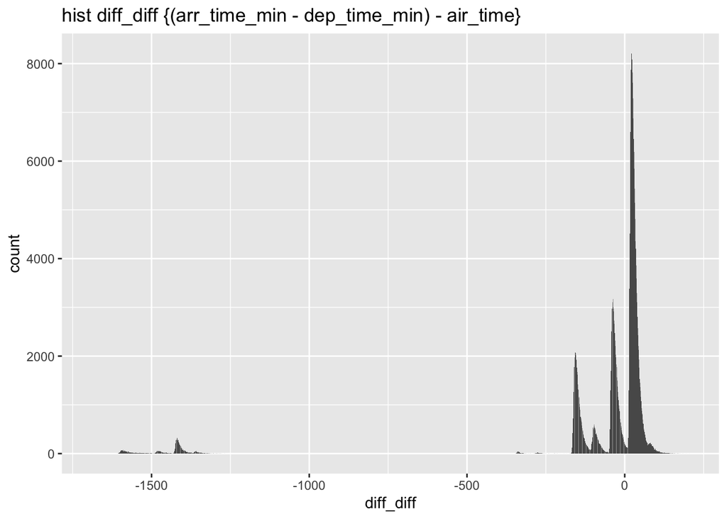

```r
ggplot(data=not_cancelled) + geom_bar(mapping = aes(x = diff_diff)) + labs(title = "hist diff_diff {(arr_time_min - dep_time_min) - air_time}")
```

3. We expect `air_time` and `arr_time_min - dep_time_min` to be the same, but they’re not. Why not? Identify a major data issue and subtle one.
- Major issue : (1) Some of the results of `arr_time_min - dep_time_min` are largely negative numbers. This comes from the cases where, flight depart before midnight but arrives after midnight.
- Subtle issue : (2) I suspect that some of data could have possibly recorded with some errors due to measurement differences. For instance, `air_time` only measures the duration in the sky, whereas `arr_time` has some time included such as driving time after landing. For example, if you look at the observation #180085(2013/9/28 by AA1256 N3BGAA, LGA to MIA both in East time zone), `air_time` is 138(2 hr 18min) where as `dep_time` 1200, `arr_time` 1518(which should have been 1418 because they are in the same time zone).
- Subtle issue : (3) `arr_time` and `dep_time` are recorded in local time zones. So subtracting them does not give an accurate measure of `air_time` except in the case where the destination is also in East time zone(GMT-4).

```r
#Major issue(1) 10536 observations with which arr_time < dep_time; which departed before midnight but arrives after midnight, resulting negative difference.
not_cancelled %>%
  filter(arr_time_min < dep_time_min)
```

```
## # A tibble: 10,536 x 23
##    arr_time_min dep_time_min  diff air_time diff_diff  year month   day
##           <dbl>        <dbl> <dbl>    <dbl>     <dbl> <int> <int> <int>
##  1            3         1169 -1166      192     -1358  2013     1     1
##  2            8         1258 -1250      159     -1409  2013     1     1
##  3          106         1262 -1156      199     -1355  2013     1     1
##  4           25         1268 -1243      354     -1597  2013     1     1
##  5           16         1280 -1264      160     -1424  2013     1     1
##  6            6         1281 -1275      143     -1418  2013     1     1
##  7           26         1288 -1262      338     -1600  2013     1     1
##  8           20         1294 -1274      152     -1426  2013     1     1
##  9           25         1296 -1271      154     -1425  2013     1     1
## 10          130         1300 -1170      189     -1359  2013     1     1
## # … with 10,526 more rows, and 15 more variables: dep_time <int>,
## #   sched_dep_time <int>, dep_delay <dbl>, arr_time <int>,
## #   sched_arr_time <int>, arr_delay <dbl>, carrier <chr>, flight <int>,
## #   tailnum <chr>, origin <chr>, dest <chr>, distance <dbl>, hour <dbl>,
## #   minute <dbl>, time_hour <dttm>
```

```r
  #diff(arr_time_min - dep_time_min) summary statistics
    not_cancelled %>%
   filter(arr_time_min < dep_time_min) %>%
   summarise(mean = mean(diff), #-1269.969
             min = min(diff), #-1401
             median = median(diff), #-1268
            max = max(diff), #-1041
            sd = sd(diff)) #59.28218
```

```
## # A tibble: 1 x 5
##     mean   min median   max    sd
##    <dbl> <dbl>  <dbl> <dbl> <dbl>
## 1 -1270. -1401  -1268 -1041  59.3
```

```r
not_cancelled %>% filter(dest == "MIA") #Subtle issue(2)NYC to Miami suggests that there some measurement differences between air_time and and 'arr_time_min - dep_time_min'. This could possibly the time difference coming from driving time after landing on the airport.
```

```
## # A tibble: 11,593 x 23
##    arr_time_min dep_time_min  diff air_time diff_diff  year month   day
##           <dbl>        <dbl> <dbl>    <dbl>     <dbl> <int> <int> <int>
##  1          563          342   221      160        61  2013     1     1
##  2          538          366   172      152        20  2013     1     1
##  3          538          367   171      157        14  2013     1     1
##  4          560          383   177      153        24  2013     1     1
##  5          602          415   187      161        26  2013     1     1
##  6          608          419   189      159        30  2013     1     1
##  7          656          473   183      157        26  2013     1     1
##  8          657          479   178      158        20  2013     1     1
##  9          696          506   190      160        30  2013     1     1
## 10          742          536   206      158        48  2013     1     1
## # … with 11,583 more rows, and 15 more variables: dep_time <int>,
## #   sched_dep_time <int>, dep_delay <dbl>, arr_time <int>,
## #   sched_arr_time <int>, arr_delay <dbl>, carrier <chr>, flight <int>,
## #   tailnum <chr>, origin <chr>, dest <chr>, distance <dbl>, hour <dbl>,
## #   minute <dbl>, time_hour <dttm>
```

4. Implement your fix to the major probelm. Remake the plot from the previous question.
- I am adding 1440(24*60) to arr_time_min with observations that are `arr_time_min < dep_time_min` to adjust for the major problem arose by midnight minute counting. With this adjustment, plot looks better in terms of extreme difference that existed in the original plot.

```r
not_cancelled <- not_cancelled %>%
  mutate(new_arr_time_min = ifelse((arr_time_min < dep_time_min), arr_time_min + 24*60, arr_time_min)) %>%
  select(new_arr_time_min, everything()) %>%
  mutate(new_diff = new_arr_time_min - dep_time_min,
         new_diff_diff = new_diff - air_time)
```

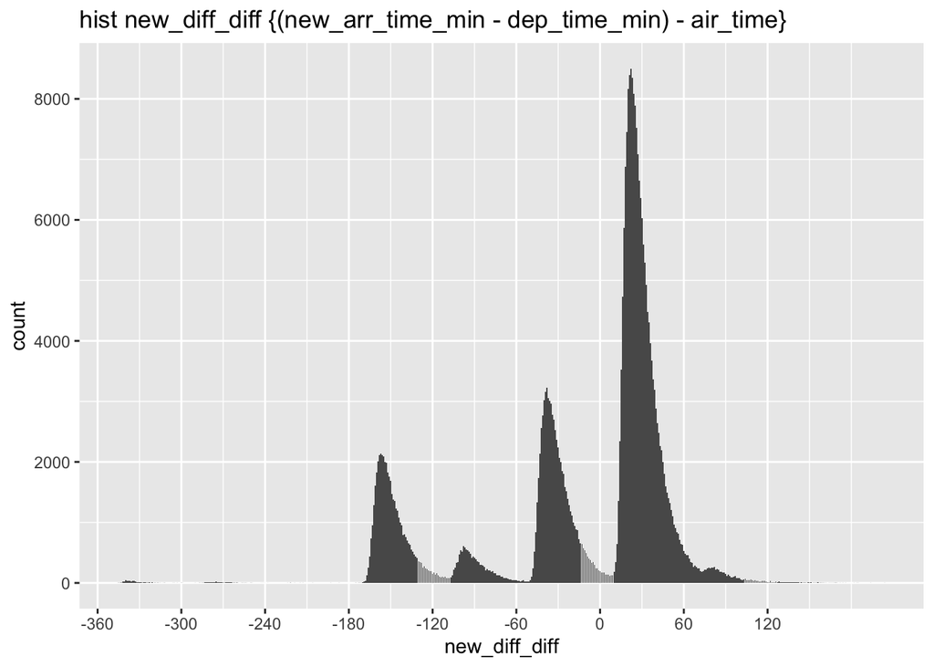

```r
ggplot(not_cancelled) + geom_bar(mapping = aes(x = new_diff_diff)) + labs(title = "hist new_diff_diff {(new_arr_time_min - dep_time_min) - air_time}") + scale_x_continuous(breaks=seq(-480, 120, by = 60))
```

```r
(filter(not_cancelled, new_diff_diff < -360 & new_diff_diff > 360)) #0% have an error.
```

```
## # A tibble: 0 x 26
## # … with 26 variables: new_arr_time_min <dbl>, arr_time_min <dbl>,
## #   dep_time_min <dbl>, diff <dbl>, air_time <dbl>, diff_diff <dbl>,
## #   year <int>, month <int>, day <int>, dep_time <int>,
## #   sched_dep_time <int>, dep_delay <dbl>, arr_time <int>,
## #   sched_arr_time <int>, arr_delay <dbl>, carrier <chr>, flight <int>,
## #   tailnum <chr>, origin <chr>, dest <chr>, distance <dbl>, hour <dbl>,
## #   minute <dbl>, time_hour <dttm>, new_diff <dbl>, new_diff_diff <dbl>
```

6. Find the 10 most delayed flights using a ranking function. How do you want to handle ties? Carefully read the documentation for min_rank().

```r
#Ties gets the smallest rank this code
head(arrange(flights,desc(min_rank(flights$dep_delay))), 10)
```

```
## # A tibble: 10 x 23
##     year month   day dep_time sched_dep_time dep_delay arr_time
##    <int> <int> <int>    <int>          <int>     <dbl>    <int>
##  1  2013     1     9      641            900      1301     1242
##  2  2013     6    15     1432           1935      1137     1607
##  3  2013     1    10     1121           1635      1126     1239
##  4  2013     9    20     1139           1845      1014     1457
##  5  2013     7    22      845           1600      1005     1044
##  6  2013     4    10     1100           1900       960     1342
##  7  2013     3    17     2321            810       911      135
##  8  2013     6    27      959           1900       899     1236
##  9  2013     7    22     2257            759       898      121
## 10  2013    12     5      756           1700       896     1058
## # … with 16 more variables: sched_arr_time <int>, arr_delay <dbl>,
## #   carrier <chr>, flight <int>, tailnum <chr>, origin <chr>, dest <chr>,
## #   air_time <dbl>, distance <dbl>, hour <dbl>, minute <dbl>,
## #   time_hour <dttm>, dep_time_min <dbl>, arr_time_min <dbl>, diff <dbl>,
## #   diff_diff <dbl>
```

# 3.6 Summarizing grouped data

1. In lecture, we defined a not_cancelled data frame. Come up with another approach that will give you the same output as not_cancelled %>% count(dest) and not_cancelled %>% count(tailnum, wt = distance) (without using count()).

```r
not_cancelled <- filter(flights, !is.na(dep_delay), !is.na(arr_delay))
not_cancelled %>% count(dest)
```

```
## # A tibble: 104 x 2
##    dest      n
##    <chr> <int>
##  1 ABQ     254
##  2 ACK     264
##  3 ALB     418
##  4 ANC       8
##  5 ATL   16837
##  6 AUS    2411
##  7 AVL     261
##  8 BDL     412
##  9 BGR     358
## 10 BHM     269
## # … with 94 more rows
```

```r
#alternative approach
not_cancelled %>%
  group_by(dest) %>%
  summarise(n = n())
```

```
## # A tibble: 104 x 2
##    dest      n
##    <chr> <int>
##  1 ABQ     254
##  2 ACK     264
##  3 ALB     418
##  4 ANC       8
##  5 ATL   16837
##  6 AUS    2411
##  7 AVL     261
##  8 BDL     412
##  9 BGR     358
## 10 BHM     269
## # … with 94 more rows
```

```r
not_cancelled %>% count(tailnum, wt = distance)
```

```
## # A tibble: 4,037 x 2
##    tailnum      n
##    <chr>    <dbl>
##  1 D942DN    3418
##  2 N0EGMQ  239143
##  3 N10156  109664
##  4 N102UW   25722
##  5 N103US   24619
##  6 N104UW   24616
##  7 N10575  139903
##  8 N105UW   23618
##  9 N107US   21677
## 10 N108UW   32070
## # … with 4,027 more rows
```

```r
#alternative approach
not_cancelled %>%
  group_by(tailnum) %>%
  summarise(n = sum(distance))
```

```
## # A tibble: 4,037 x 2
##    tailnum      n
##    <chr>    <dbl>
##  1 D942DN    3418
##  2 N0EGMQ  239143
##  3 N10156  109664
##  4 N102UW   25722
##  5 N103US   24619
##  6 N104UW   24616
##  7 N10575  139903
##  8 N105UW   23618
##  9 N107US   21677
## 10 N108UW   32070
## # … with 4,027 more rows
```

2. Calculate average delays by destination for flights originating in NYC. Create a variable which ranks destinations from worst to best, where 1 is the worst rank.
- I calculated average delays by destination with arr_delay. Because we want look at the case for the destination’s delayed time and arrival delay matters for the destination rather than destination delay.

```r
by_destination <-
  not_cancelled %>%
  group_by(dest) %>%
  summarise(delay = mean(arr_delay, na.rm = TRUE)) %>%
  arrange(desc(delay))
by_destination
```

```
## # A tibble: 104 x 2
##    dest  delay
##    <chr> <dbl>
##  1 CAE    41.8
##  2 TUL    33.7
##  3 OKC    30.6
##  4 JAC    28.1
##  5 TYS    24.1
##  6 MSN    20.2
##  7 RIC    20.1
##  8 CAK    19.7
##  9 DSM    19.0
## 10 GRR    18.2
## # … with 94 more rows
```

3. What hour of the day should you fly if you want to avoid arrival delays as much as possible?
- Analyzing by time of scheduled departure(hour), flying approximately at 7 can avoid arrival delay as much as possible. Because on average plane scheduled to depart at approximately 7 arrives earlier than the schedule.

```r
by_hour <-
  not_cancelled %>%
  group_by(hour) %>%
  summarise(delay = mean(arr_delay, na.rm = TRUE)) %>%
  arrange(delay)
by_hour
```

```
## # A tibble: 19 x 2
##     hour  delay
##    <dbl>  <dbl>
##  1     7 -5.30
##  2     5 -4.80
##  3     6 -3.38
##  4     9 -1.45
##  5     8 -1.11
##  6    10  0.954
##  7    11  1.48
##  8    12  3.49
##  9    13  6.54
## 10    14  9.20
## 11    23 11.8
## 12    15 12.3
## 13    16 12.6
## 14    18 14.8
## 15    22 16.0
## 16    17 16.0
## 17    19 16.7
## 18    20 16.7
## 19    21 18.4
```

4. Which plane (tailnum) has the most minutes of delays total?
- N15910 has the 15075 minutes of delay, which ranks the first most minutes of total delays.

```r
by_tail <-
  not_cancelled %>%
  group_by(tailnum) %>%
  summarise(total_delay = sum(dep_delay, arr_delay, na.rm = TRUE)) %>%
  arrange(desc(total_delay))
by_tail
```

```
## # A tibble: 4,037 x 2
##    tailnum total_delay
##    <chr>         <dbl>
##  1 N15910        15075
##  2 N15980        14660
##  3 N228JB        14318
##  4 N16919        13923
##  5 N14998        12442
##  6 N192JB        12405
##  7 N258JB        12299
##  8 N292JB        12111
##  9 N12921        11925
## 10 N13913        11924
## # … with 4,027 more rows
```

5. Find all destinations that are flown by at least three carriers. Order the results from most carriers to fewest.
- Below lists are 52 destinations that are flown by at least 3 carriers in descending order.

```r
not_cancelled %>%
  group_by(dest) %>%
  summarise(carriers = n_distinct(carrier)) %>%
  arrange(desc(carriers)) %>%
  filter(carriers >= 3)
```

```
## # A tibble: 52 x 2
##    dest  carriers
##    <chr>    <int>
##  1 ATL          7
##  2 BOS          7
##  3 CLT          7
##  4 ORD          7
##  5 TPA          7
##  6 AUS          6
##  7 DCA          6
##  8 DTW          6
##  9 IAD          6
## 10 MSP          6
## # … with 42 more rows
```

6. Calculate the number of non-cancelled flights by each carrier. Report the results in table in reverse alphabetical order with the min() and max() distance each airline covers.

```r
by_carrier <-
  not_cancelled %>%
  group_by(carrier) %>%
  summarise(
    min = min(distance),
    max = max(distance)) %>%
  arrange(desc(carrier))

by_carrier
```

```
## # A tibble: 16 x 3
##    carrier   min   max
##    <chr>   <dbl> <dbl>
##  1 YV         96   544
##  2 WN        169  2133
##  3 VX       2248  2586
##  4 US         94  2153
##  5 UA        116  4963
##  6 OO        229  1008
##  7 MQ        184  1147
##  8 HA       4983  4983
##  9 FL        397   762
## 10 F9       1620  1620
## 11 EV         80  1389
## 12 DL         94  2586
## 13 B6        173  2586
## 14 AS       2402  2402
## 15 AA        187  2586
## 16 9E         94  1587
```

7. Which airlines only offer flights from New York to one other airport?
- AS, F9, HA are the airlines that only offer flights from New York to one other airport.

```r
by_airlines <-
  not_cancelled %>%
  group_by(carrier, dest) %>%
  summarise(count = n()) %>%
  group_by(carrier) %>%
  summarise(count = n()) %>%
  filter(count <= 1)

by_airlines
```

```
## # A tibble: 3 x 2
##   carrier count
##   <chr>   <int>
## 1 AS          1
## 2 F9          1
## 3 HA          1
```

# 3.7 Practical application

1. We posit that arrival delays are more important than departure delays from a passanger’s perspective. We are interested in determining what airlines to avoid based on their delay characteristics.
1. Calculate the median arrival delay by airline.

```r
not_cancelled %>%
  group_by(carrier) %>%
  summarise(
    median_arr_delay = quantile(arr_delay, 0.5)
  )
```

```
## # A tibble: 16 x 2
##    carrier median_arr_delay
##    <chr>              <dbl>
##  1 9E                    -7
##  2 AA                    -9
##  3 AS                   -17
##  4 B6                    -3
##  5 DL                    -8
##  6 EV                    -1
##  7 F9                     6
##  8 FL                     5
##  9 HA                   -13
## 10 MQ                    -1
## 11 OO                    -7
## 12 UA                    -6
## 13 US                    -6
## 14 VX                    -9
## 15 WN                    -3
## 16 YV                    -2
```

```r
not_cancelled %>%
  group_by(carrier) %>%
  summarise(
    median_delay = median(arr_delay),
    sd_arr_delay = mad(arr_delay),
    mean_delay = mean(arr_delay),
    iqr_delay = IQR(arr_delay),
    mad_delay = mad(arr_delay)
  )
```

```
## # A tibble: 16 x 6
##    carrier median_delay sd_arr_delay mean_delay iqr_delay mad_delay
##    <chr>          <dbl>        <dbl>      <dbl>     <dbl>     <dbl>
##  1 9E                -7         23.7      7.38       36        23.7
##  2 AA                -9         20.8      0.364      29        20.8
##  3 AS               -17         25.2     -9.93       34        25.2
##  4 B6                -3         20.8      9.46       31        20.8
##  5 DL                -8         19.3      1.64       28        19.3
##  6 EV                -1         23.7     15.8        40        23.7
##  7 F9                 6         26.7     21.9        40        26.7
##  8 FL                 5         20.8     20.1        31        20.8
##  9 HA               -13         22.2     -6.92       30.5      22.2
## 10 MQ                -1         20.8     10.8        31        20.8
## 11 OO                -7         14.8     11.9        22        14.8
## 12 UA                -6         20.8      3.56       30        20.8
## 13 US                -6         16.3      2.13       23        16.3
## 14 VX                -9         22.2      1.76       31        22.2
## 15 WN                -3         20.8      9.65       30        20.8
## 16 YV                -2         25.2     15.6        40.2      25.2
```